# Confirmatory Factor Analysis

Burak Tunca, PhD

Lund, Fall 2018

> Note: This document is based on the “semoutput” R package developed by Jason Tsukahara. For more information please see: https://github.com/dr-JT/semoutput

# Confirmatory Factor Analysis

## Dataset

For this exercise we will be using the “Political Democracy” dataset. For more information about this dataset run the following code in the R Console:

```r
#load the political democracy dataset
data <- PoliticalDemocracy

#View first few rows of the dataset
head(data)
```

```
##      y1       y2       y3       y4       y5       y6       y7       y8
## 1  2.50 0.000000 3.333333 0.000000 1.250000 0.000000 3.726360 3.333333
## 2  1.25 0.000000 3.333333 0.000000 6.250000 1.100000 6.666666 0.736999
## 3  7.50 8.800000 9.999998 9.199991 8.750000 8.094061 9.999998 8.211809
## 4  8.90 8.800000 9.999998 9.199991 8.907948 8.127979 9.999998 4.615086
## 5 10.00 3.333333 9.999998 6.666666 7.500000 3.333333 9.999998 6.666666
## 6  7.50 3.333333 6.666666 6.666666 6.250000 1.100000 6.666666 0.368500
##         x1       x2       x3
## 1 4.442651 3.637586 2.557615
## 2 5.384495 5.062595 3.568079
## 3 5.961005 6.255750 5.224433
## 4 6.285998 7.567863 6.267495
## 5 5.863631 6.818924 4.573679
## 6 5.533389 5.135798 3.892270
```

```r
#descriptive statistics of the dataset
descriptives(data)
```

Descriptive Statistics

| Variable | n | Mean | SD | min | max | % Missing |
| --- | --- | --- | --- | --- | --- | --- |
| x1 | 75 | 5.05 | 0.73 | 3.78 | 6.74 | 0 |
| x2 | 75 | 4.79 | 1.51 | 1.39 | 7.87 | 0 |
| x3 | 75 | 3.56 | 1.41 | 1.00 | 6.42 | 0 |
| y1 | 75 | 5.46 | 2.62 | 1.25 | 10.00 | 0 |
| y2 | 75 | 4.26 | 3.95 | 0.00 | 10.00 | 0 |
| y3 | 75 | 6.56 | 3.28 | 0.00 | 10.00 | 0 |
| y4 | 75 | 4.45 | 3.35 | 0.00 | 10.00 | 0 |
| y5 | 75 | 5.14 | 2.61 | 0.00 | 10.00 | 0 |
| y6 | 75 | 2.98 | 3.37 | 0.00 | 10.00 | 0 |
| y7 | 75 | 6.20 | 3.29 | 0.00 | 10.00 | 0 |
| y8 | 75 | 4.04 | 3.25 | 0.00 | 10.00 | 0 |

```r
descr(data)
```

```
## Descriptive Statistics
## Data Frame: data
## N: 75
##
##                         y1       y2       y3       y4       y5       y6       y7       y8       x1
## ----------------- -------- -------- -------- -------- -------- -------- -------- -------- --------
##              Mean     5.46     4.26     6.56     4.45     5.14     2.98     6.20     4.04     5.05
##           Std.Dev     2.62     3.95     3.28     3.35     2.61     3.37     3.29     3.25     0.73
##               Min     1.25     0.00     0.00     0.00     0.00     0.00     0.00     0.00     3.78
##                Q1     2.90     0.00     3.33     1.50     3.63     0.00     3.33     1.12     4.48
##            Median     5.40     3.33     6.67     3.33     5.00     2.23     6.67     3.33     5.08
##                Q3     7.50     8.80    10.00     6.67     7.50     4.36    10.00     6.67     5.52
##               Max    10.00    10.00    10.00    10.00    10.00    10.00    10.00    10.00     6.74
##               MAD     3.11     4.94     4.94     4.94     3.71     3.31     4.94     4.40     0.82
##               IQR     4.60     8.28     6.23     5.09     3.81     4.21     6.52     5.37     1.04
##                CV     0.48     0.93     0.50     0.75     0.51     1.13     0.53     0.80     0.15
##          Skewness    -0.09     0.32    -0.59     0.12    -0.23     0.89    -0.55     0.45     0.25
##       SE.Skewness     0.28     0.28     0.28     0.28     0.28     0.28     0.28     0.28     0.28
##          Kurtosis    -1.15    -1.47    -0.72    -1.21    -0.78    -0.47    -0.73    -0.96    -0.75
##           N.Valid    75.00    75.00    75.00    75.00    75.00    75.00    75.00    75.00    75.00
##         Pct.Valid   100.00   100.00   100.00   100.00   100.00   100.00   100.00   100.00   100.00
##
## Table: Table continues below
##
##
##
##                         x2       x3
## ----------------- -------- --------
##              Mean     4.79     3.56
##           Std.Dev     1.51     1.41
##               Min     1.39     1.00
##                Q1     3.64     2.26
##            Median     4.96     3.57
##                Q3     5.84     4.54
##               Max     7.87     6.42
##               MAD     1.53     1.51
##               IQR     2.17     2.22
##                CV     0.32     0.40
##          Skewness    -0.35     0.08
##       SE.Skewness     0.28     0.28
##          Kurtosis    -0.57    -0.94
##           N.Valid    75.00    75.00
##         Pct.Valid   100.00   100.00
```

```r
view(dfSummary(data))
```

```
## Method 'viewer' only valid within RStudio. Switching method to 'browser'.
```

```
## Output file written: C:\Users\BT\AppData\Local\Temp\RtmpausblH\file1f68603c4720.html
```

```r
#correlations between the variables
round(cor(data),2)
```

```
##      y1   y2   y3   y4   y5   y6   y7   y8   x1   x2   x3
## y1 1.00 0.60 0.68 0.69 0.74 0.65 0.67 0.67 0.38 0.32 0.25
## y2 0.60 1.00 0.45 0.72 0.54 0.71 0.58 0.61 0.21 0.25 0.21
## y3 0.68 0.45 1.00 0.61 0.58 0.43 0.65 0.53 0.33 0.31 0.23
## y4 0.69 0.72 0.61 1.00 0.65 0.66 0.68 0.74 0.47 0.44 0.39
## y5 0.74 0.54 0.58 0.65 1.00 0.56 0.68 0.63 0.56 0.52 0.43
## y6 0.65 0.71 0.43 0.66 0.56 1.00 0.61 0.75 0.34 0.35 0.33
## y7 0.67 0.58 0.65 0.68 0.68 0.61 1.00 0.71 0.39 0.40 0.35
## y8 0.67 0.61 0.53 0.74 0.63 0.75 0.71 1.00 0.46 0.46 0.37
## x1 0.38 0.21 0.33 0.47 0.56 0.34 0.39 0.46 1.00 0.89 0.80
## x2 0.32 0.25 0.31 0.44 0.52 0.35 0.40 0.46 0.89 1.00 0.85
## x3 0.25 0.21 0.23 0.39 0.43 0.33 0.35 0.37 0.80 0.85 1.00
```

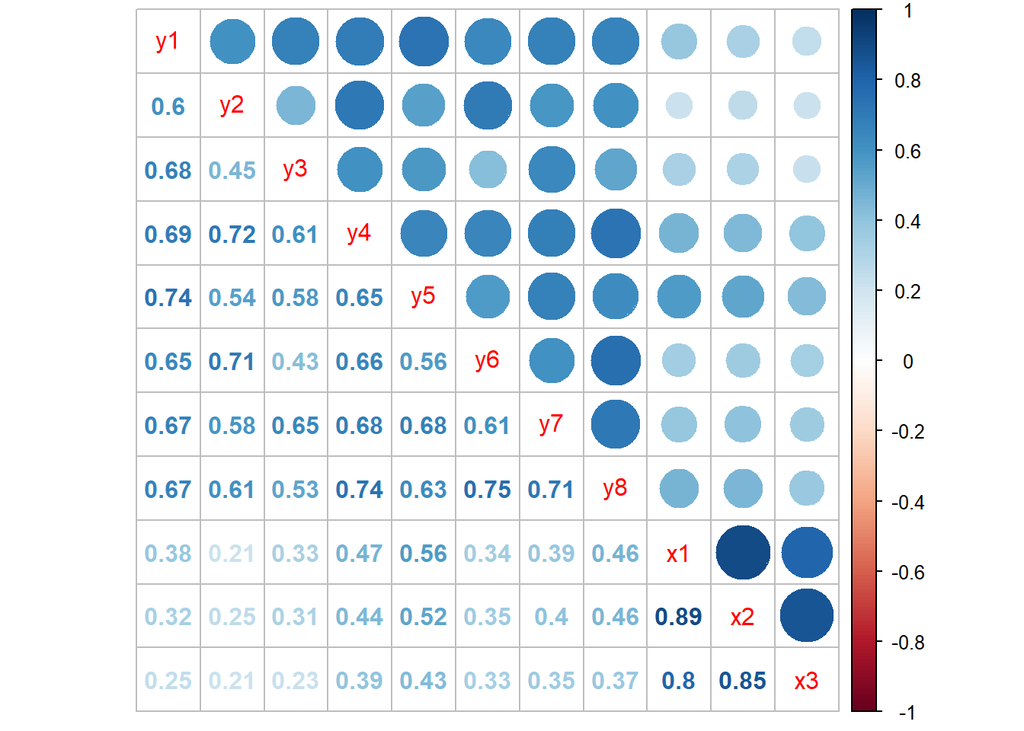

```r
#fancy correlations with the corrplot package
M <- cor(data)
corrplot.mixed(M)
```

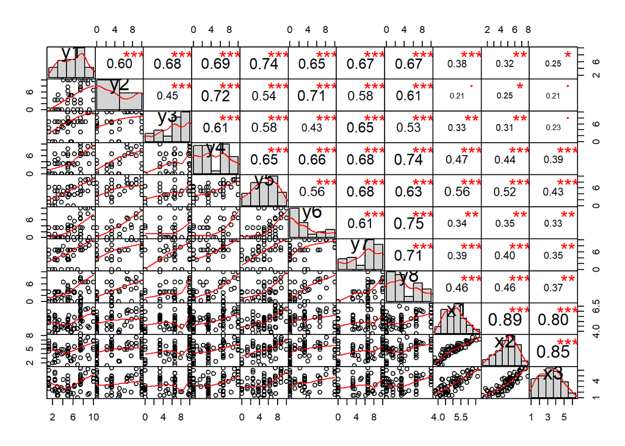

```r
#fancy correlations with the PerformanceAnalytics Package
chart.Correlation(data)
```

## One Factor Models

We would like to model the latent factor “Industrialization in 1960” with the following manifest variables:

- x1 The gross national product (GNP) per capita in 1960
- x2 The inanimate energy consumption per capita in 1960
- x3 The percentage of the labor force in industry in 1960

```r
# factors is a list of the latent factor names. To be used for printing lavaan output to nice looking tables.
# name the latent factor "ind60"
factors <- c("ind60")

# Specify the model parameters. Name the model "ind60model"
ind60model <- "ind60 =~ x1 + x2 + x3"

# CFA for our model "ind60model"
ind60fit <- cfa(model=ind60model, data=data,
                mimic="lavaan", missing="ML", std.lv = FALSE)

summary(ind60fit, standardized=TRUE, fit.measures=TRUE)
```

```
## lavaan 0.6-3 ended normally after 30 iterations
##
##   Optimization method                           NLMINB
##   Number of free parameters                          9
##
##   Number of observations                            75
##   Number of missing patterns                         1
##
##   Estimator                                         ML
##   Model Fit Test Statistic                       0.000
##   Degrees of freedom                                 0
##   Minimum Function Value               0.0000000000000
##
## Model test baseline model:
##
##   Minimum Function Test Statistic              219.165
##   Degrees of freedom                                 3
##   P-value                                        0.000
##
## User model versus baseline model:
##
##   Comparative Fit Index (CFI)                    1.000
##   Tucker-Lewis Index (TLI)                       1.000
##
## Loglikelihood and Information Criteria:
##
##   Loglikelihood user model (H0)               -241.345
##   Loglikelihood unrestricted model (H1)       -241.345
##
##   Number of free parameters                          9
##   Akaike (AIC)                                 500.690
##   Bayesian (BIC)                               521.547
##   Sample-size adjusted Bayesian (BIC)          493.182
##
## Root Mean Square Error of Approximation:
##
##   RMSEA                                          0.000
##   90 Percent Confidence Interval          0.000  0.000
##   P-value RMSEA <= 0.05                             NA
##
```

[output cut: 15 more lines]

```
##     x3                1.824    0.153   11.883    0.000    1.217    0.872
##
## Intercepts:
##                    Estimate  Std.Err  z-value  P(>|z|)   Std.lv  Std.all
##    .x1                5.054    0.084   60.127    0.000    5.054    6.943
##    .x2                4.792    0.173   27.657    0.000    4.792    3.194
##    .x3                3.558    0.161   22.066    0.000    3.558    2.548
##     ind60             0.000                               0.000    0.000
##
## Variances:
##                    Estimate  Std.Err  z-value  P(>|z|)   Std.lv  Std.all
##    .x1                0.084    0.020    4.140    0.000    0.084    0.159
##    .x2                0.108    0.074    1.455    0.146    0.108    0.048
##    .x3                0.468    0.091    5.124    0.000    0.468    0.240
##     ind60             0.446    0.087    5.135    0.000    1.000    1.000
```

### Summary Output

```r
## This tab will print out summary result tables with the most important information. Fit stats, standardized path values, etc...
sem.sig(ind60fit)
```

Model Significance

| Sample.Size | Chi.Square | df | p.value |
| --- | --- | --- | --- |
| 75 | 0 | 0 | NA |

```r
sem.fitmeasures(ind60fit)
```

Model Fit Measures

| CFI | RMSEA | RMSEA.Lower | RMSEA.Upper | AIC | BIC |
| --- | --- | --- | --- | --- | --- |
| 1 | 0 | 0 | 0 | 500.69 | 521.547 |

```r
sem.factorloadings(ind60fit)
```

Factor Loadings

| Latent Factor | Indicator | Loadings Standardized | Loadings Unstandardized | SE | z | sig |
| --- | --- | --- | --- | --- | --- | --- |
| ind60 | x1 | 0.917 | 1.000 | 0.000 | NA | NA |
| ind60 | x2 | 0.976 | 2.193 | 0.142 | 15.403 | *** |
| ind60 | x3 | 0.872 | 1.824 | 0.153 | 11.883 | *** |

```r
sem.factorcor(ind60fit, factors = factors)
```

Latent Factor Correlations

| Factor 1 | Factor 2 | r | sig |
| --- | --- | --- | --- |

```r
sem.factorvar(ind60fit, factors = factors)
```

Latent Factor Variance/Residual Variance

| Factor 1 | Factor 2 | var | var.std | sig |
| --- | --- | --- | --- | --- |
| ind60 | ind60 | 0.446 | 1 | *** |

```r
sem.rsquared(ind60fit)
```

R-Squared Values

| Variable | R-Squared |
| --- | --- |
| x1 | 0.8405877 |
| x2 | 0.9518611 |
| x3 | 0.7599364 |

### Path Diagram

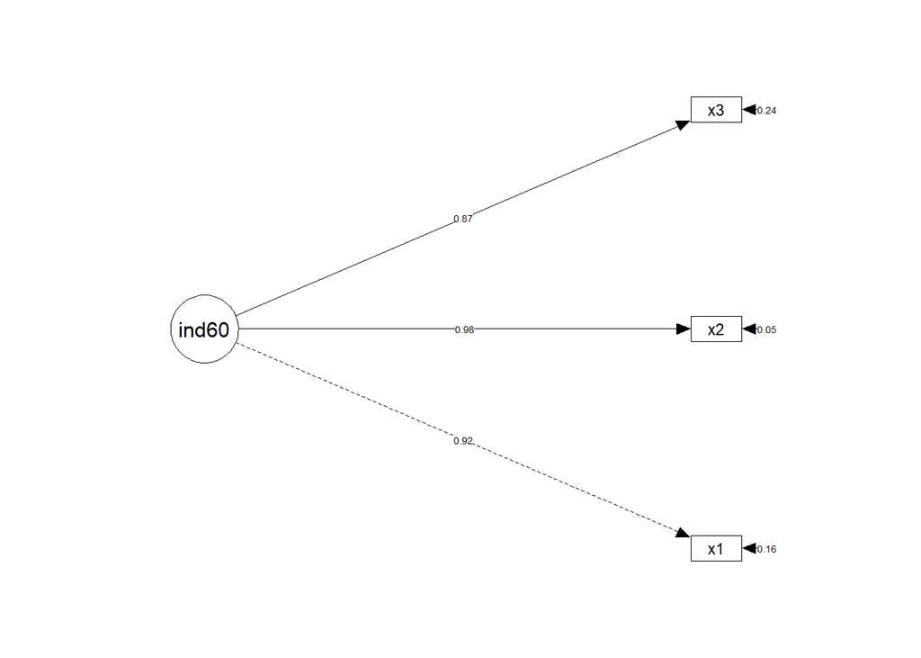

```r
## This tab will print out a model diagram.
semPaths(ind60fit, latents = factors,
         whatLabels = "std", edge.label.cex = .5, layout = "tree", rotation = 2,
         style = "lisrel", intercepts = FALSE, residuals = TRUE, curve = 1,
         curvature = 3, nCharNodes = 8, sizeMan = 6, sizeMan2 = 3,
         optimizeLatRes = TRUE, edge.color = "#000000")
```

## Multi-Factor Models

- y1 Expert ratings of the freedom of the press in 1960
- y2 The freedom of political opposition in 1960
- y3 The fairness of elections in 1960
- y4 The effectiveness of the elected legislature in 1960
- y5 Expert ratings of the freedom of the press in 1965
- y6 The freedom of political opposition in 1965
- y7 The fairness of elections in 1965
- y8 The effectiveness of the elected legislature in 1965

```r
# name the latent factors
factors <- c("ind60", "dem60")

# Specify the model parameters. Name the model "cfamodel"
cfamodel <- "
            ind60 =~ x1 + x2 + x3
            dem60 =~ y1 + y2 + y3 + y4
            "

# CFA for our model
cfafit <- cfa(model=cfamodel, data=data,
               mimic="lavaan", missing="ML", std.lv = FALSE)

summary(cfafit, standardized=TRUE, fit.measures=TRUE)
```

```
## lavaan 0.6-3 ended normally after 47 iterations
##
##   Optimization method                           NLMINB
##   Number of free parameters                         22
##
##   Number of observations                            75
##   Number of missing patterns                         1
##
##   Estimator                                         ML
##   Model Fit Test Statistic                      23.738
##   Degrees of freedom                                13
##   P-value (Chi-square)                           0.034
##
## Model test baseline model:
##
##   Minimum Function Test Statistic              406.880
##   Degrees of freedom                                21
##   P-value                                        0.000
##
## User model versus baseline model:
##
##   Comparative Fit Index (CFI)                    0.972
##   Tucker-Lewis Index (TLI)                       0.955
##
## Loglikelihood and Information Criteria:
##
##   Loglikelihood user model (H0)               -938.083
##   Loglikelihood unrestricted model (H1)       -926.214
##
##   Number of free parameters                         22
##   Akaike (AIC)                                1920.165
##   Bayesian (BIC)                              1971.150
##   Sample-size adjusted Bayesian (BIC)         1901.812
##
## Root Mean Square Error of Approximation:
##
##   RMSEA                                          0.105
##   90 Percent Confidence Interval          0.029  0.171
##   P-value RMSEA <= 0.05                          0.093
##
```

[output cut: 35 more lines]

```
##    .y4                4.453    0.384   11.590    0.000    4.453    1.338
##     ind60             0.000                               0.000    0.000
##     dem60             0.000                               0.000    0.000
##
## Variances:
##                    Estimate  Std.Err  z-value  P(>|z|)   Std.lv  Std.all
##    .x1                0.081    0.020    4.074    0.000    0.081    0.154
##    .x2                0.120    0.072    1.671    0.095    0.120    0.053
##    .x3                0.467    0.089    5.215    0.000    0.467    0.239
##    .y1                2.404    0.585    4.108    0.000    2.404    0.354
##    .y2                6.552    1.286    5.093    0.000    6.552    0.426
##    .y3                5.363    1.053    5.092    0.000    5.363    0.505
##    .y4                2.137    0.821    2.603    0.009    2.137    0.193
##     ind60             0.449    0.087    5.167    0.000    1.000    1.000
##     dem60             4.382    1.124    3.900    0.000    1.000    1.000
```

### Summary Output

```r
## This tab will print out summary result tables with the most important information. Fit stats, standardized path values, etc...
sem.sig(cfafit)
```

Model Significance

| Sample.Size | Chi.Square | df | p.value |
| --- | --- | --- | --- |
| 75 | 23.738 | 13 | 0.034 |

```r
sem.fitmeasures(cfafit)
```

Model Fit Measures

| CFI | RMSEA | RMSEA.Lower | RMSEA.Upper | AIC | BIC |
| --- | --- | --- | --- | --- | --- |
| 0.972 | 0.105 | 0.029 | 0.171 | 1920.165 | 1971.15 |

```r
sem.factorloadings(cfafit)
```

Factor Loadings

| Latent Factor | Indicator | Loadings Standardized | Loadings Unstandardized | SE | z | sig |
| --- | --- | --- | --- | --- | --- | --- |
| ind60 | x1 | 0.920 | 1.000 | 0.000 | NA | NA |
| ind60 | x2 | 0.973 | 2.180 | 0.140 | 15.576 | *** |
| ind60 | x3 | 0.872 | 1.818 | 0.152 | 11.946 | *** |
| dem60 | y1 | 0.804 | 1.000 | 0.000 | NA | NA |
| dem60 | y2 | 0.757 | 1.419 | 0.212 | 6.693 | *** |
| dem60 | y3 | 0.704 | 1.095 | 0.167 | 6.568 | *** |
| dem60 | y4 | 0.898 | 1.428 | 0.190 | 7.495 | *** |

```r
sem.factorcor(cfafit, factors = factors, standardized = TRUE)
```

Latent Factor Correlations

[output not shown]

```r
sem.factorvar(cfafit, factors = factors)
```

Latent Factor Variance/Residual Variance

| Factor 1 | Factor 2 | var | var.std | sig |
| --- | --- | --- | --- | --- |
| ind60 | ind60 | 0.449 | 1 | *** |
| dem60 | dem60 | 4.382 | 1 | *** |

```r
sem.rsquared(cfafit)
```

R-Squared Values

| Variable | R-Squared |
| --- | --- |
| x1 | 0.8463258 |
| x2 | 0.9466080 |
| x3 | 0.7606513 |
| y1 | 0.6457313 |
| y2 | 0.5737844 |
| y3 | 0.4950818 |
| y4 | 0.8069175 |

### Path Diagram

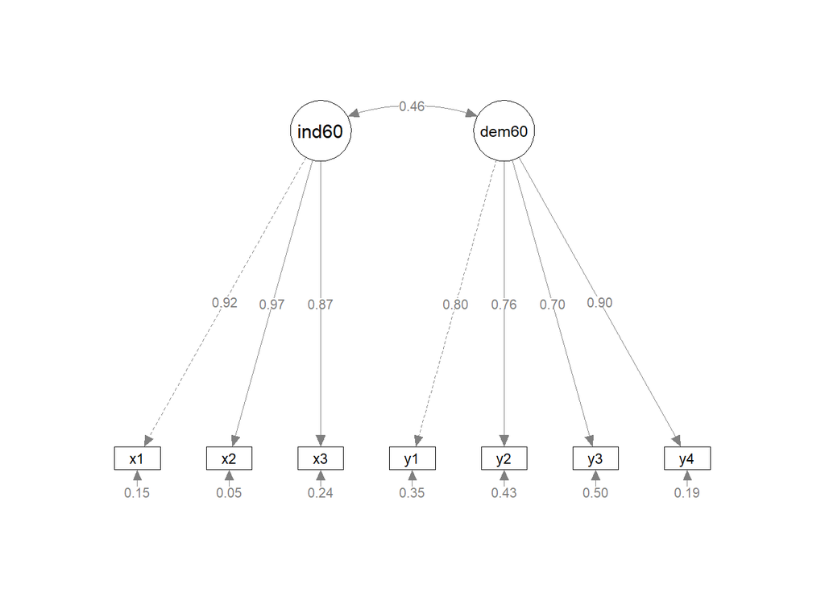

```r
## This tab will print out a model diagram.
semPaths(cfafit, latents = factors,
         whatLabels = "std", #view standardized parameters
         edge.label.cex = 0.8, #fontsize
         style = "lisrel",
         intercepts = FALSE, residuals = TRUE, curve = 1,
         curvature = 3, nCharNodes = 8, sizeMan = 6, sizeMan2 = 3,
         optimizeLatRes = TRUE)
```